# May 5

Time Series

```r
library(TSA)
library(tseries)
library(lmtest)
```

```r
data("ar2.s")
data("ma1.1.s")
#rnorm(120, mean = 0, sd = 1) #standard normal
z = ts(rnorm(120, mean = 0, sd = 1))
z
```

```
Time Series:
Start = 1
End = 120
Frequency = 1
  [1]  1.045138691  0.639613109 -1.333304966 -0.137718555 -1.125694758  0.464479048  0.813242804  0.666949629
  [9] -0.097294374 -1.453748746  1.556115083 -0.838832885  1.451273075  1.067121442  0.492906947  0.150426059
 [17]  1.133825363 -0.736954131  1.512795034 -0.727721158  0.938412519  0.635884429  0.114988206 -0.477365615
 [25] -0.412861133  0.440068449 -0.499932596 -0.121137644 -0.603516721 -2.053543193 -0.471602429 -0.051773135
 [33]  1.075377784  0.571770524  0.461505023 -0.540005860 -1.261312291 -1.454065146  1.798456280 -0.390651560
 [41]  1.767259641  1.249284082 -0.389123506 -1.556030487 -0.794716979  0.253235549  1.049937708  0.640131369
 [49]  0.212755415  1.680350596  0.169053056 -0.503553986 -0.460338549  0.326555192 -2.129559467 -3.136981417
 [57]  1.736866842  1.570290977 -0.995349317 -0.728359991 -1.088841444 -1.078666411  0.558074139  0.013826165
 [65]  1.483950839  0.376222567  0.164410314 -0.133167648 -0.115296347 -0.885533381 -1.070697204  0.177402304
 [73] -1.933435660  0.183116938 -0.310997287 -1.437348728 -0.329369317 -0.537694160 -1.450215831  0.532647538
 [81] -0.183555363 -1.450854082  0.406326243 -0.097727677  0.959494214 -0.482820295  0.866081518 -0.177482606
 [89] -0.764057569  0.090215037  1.977551279  0.503192637  0.121787230 -0.277255734 -0.448514419 -0.469236921
 [97]  0.463612163  1.239579022 -0.221018822  0.005039095 -1.169927504 -1.683849638 -0.214362873  0.508126230
[105] -0.507106499  1.149517032 -0.441123543 -0.693168954  0.293946825 -0.452338423 -2.412787143 -0.500038374
[113] -0.524246888  0.794189596 -0.590385665  2.082459101 -1.717626421  0.780766803 -0.806785675 -1.281436448
```

```r
ar2.s
```

```
Time Series:
Start = 1
End = 120
Frequency = 1
  [1] -2.0639075 -1.9374330  0.4060953  2.0385378  2.9531557  4.2480230  4.1932412  3.9284257  1.0450358
 [10] -0.8978154  0.3530501  1.6043017  2.3568422  0.5163246 -1.9048841 -3.2936143 -3.9171459 -2.2751263
 [19]  0.3406347  2.2937143  4.6388428  5.6120995  4.7681131  2.4408823  0.6287606 -1.3927067 -1.7738348
 [28] -1.3152727  0.6676909  2.7864247  4.5297293  4.2612074  2.5477394  0.6390086 -2.3884374 -4.6911722
 [37] -5.0019084 -2.9261213  0.1935982  2.5902001  1.9983884  1.7001795  1.1485822  0.3710050  0.6870215
 [46] -0.1069723 -0.9573042  0.7105202  1.1722054  1.5410308  2.0926856  0.2610528 -3.3125610 -5.0956855
 [55] -4.2912858 -4.9052087 -4.2895390 -3.0241838  0.4722106  3.6487218  4.9096236  4.6400766  4.8120140
 [64]  3.8152554  2.1923101 -0.3522374 -2.0060291 -2.4795410 -1.3240089 -0.5942460  0.8600122  1.0939665
 [73]  1.6236124  1.8632738  0.8771257 -0.6491685 -1.8929909 -3.4164950 -3.8113680 -2.3835770  2.0305640
 [82]  4.7495940  6.1450357  6.4082192  4.1948779  2.4872723  1.0408025 -1.7385007 -3.6536578 -3.5348420
 [91] -2.9770407 -2.2740052 -1.9707213 -2.4091172 -1.4247448  0.9373224  2.3313912  2.2790661  3.1529469
[100]  2.8575319  1.9632968  1.2848362 -0.7253455 -2.7152191 -4.1634694 -4.9107529 -3.6666768 -3.9300310
[109] -2.8841292 -0.2315433  1.8305755  2.6077816  1.5825446  0.8913945 -1.3636808 -2.5497861 -3.6727837
[118] -2.0035070  0.3959248  2.4538871
```

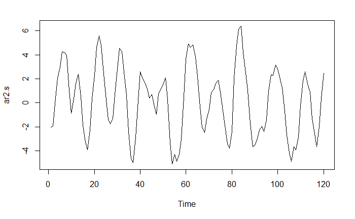

```r
plot(ar2.s)
```

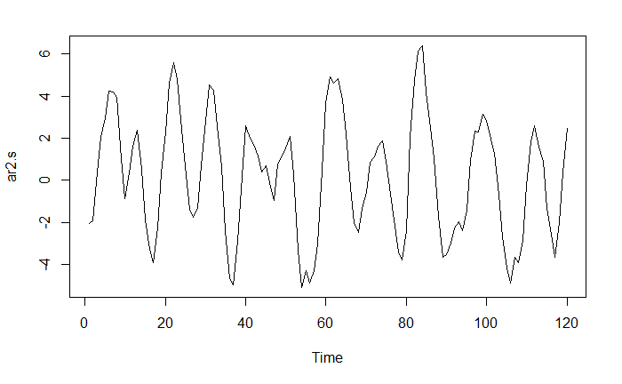

```r
plot.ts(ar2.s) # plots as a time series
```

```r
z1 = ts(z, frequency = 12) # interprets it as monthly data
z2 = ts(z, frequency = 4) # quarterly
z1
```

```
            Jan          Feb          Mar          Apr          May          Jun          Jul          Aug
1   1.045138691  0.639613109 -1.333304966 -0.137718555 -1.125694758  0.464479048  0.813242804  0.666949629
2   1.451273075  1.067121442  0.492906947  0.150426059  1.133825363 -0.736954131  1.512795034 -0.727721158
3  -0.412861133  0.440068449 -0.499932596 -0.121137644 -0.603516721 -2.053543193 -0.471602429 -0.051773135
4  -1.261312291 -1.454065146  1.798456280 -0.390651560  1.767259641  1.249284082 -0.389123506 -1.556030487
5   0.212755415  1.680350596  0.169053056 -0.503553986 -0.460338549  0.326555192 -2.129559467 -3.136981417
6  -1.088841444 -1.078666411  0.558074139  0.013826165  1.483950839  0.376222567  0.164410314 -0.133167648
7  -1.933435660  0.183116938 -0.310997287 -1.437348728 -0.329369317 -0.537694160 -1.450215831  0.532647538
8   0.959494214 -0.482820295  0.866081518 -0.177482606 -0.764057569  0.090215037  1.977551279  0.503192637
9   0.463612163  1.239579022 -0.221018822  0.005039095 -1.169927504 -1.683849638 -0.214362873  0.508126230
10  0.293946825 -0.452338423 -2.412787143 -0.500038374 -0.524246888  0.794189596 -0.590385665  2.082459101
            Sep          Oct          Nov          Dec
1  -0.097294374 -1.453748746  1.556115083 -0.838832885
2   0.938412519  0.635884429  0.114988206 -0.477365615
3   1.075377784  0.571770524  0.461505023 -0.540005860
4  -0.794716979  0.253235549  1.049937708  0.640131369
5   1.736866842  1.570290977 -0.995349317 -0.728359991
6  -0.115296347 -0.885533381 -1.070697204  0.177402304
7  -0.183555363 -1.450854082  0.406326243 -0.097727677
8   0.121787230 -0.277255734 -0.448514419 -0.469236921
9  -0.507106499  1.149517032 -0.441123543 -0.693168954
10 -1.717626421  0.780766803 -0.806785675 -1.281436448
```

same index

```r
z1[15]
```

```
[1] 0.4929069
```

```r
z2[15]
```

```
[1] 0.4929069
```

```r
z3 = ts(z, frequency = 12, start = c(2012,12), end = c(2024,3))
z3
```

```
              Jan          Feb          Mar          Apr          May          Jun          Jul          Aug
2012
2013  0.639613109 -1.333304966 -0.137718555 -1.125694758  0.464479048  0.813242804  0.666949629 -0.097294374
2014  1.067121442  0.492906947  0.150426059  1.133825363 -0.736954131  1.512795034 -0.727721158  0.938412519
2015  0.440068449 -0.499932596 -0.121137644 -0.603516721 -2.053543193 -0.471602429 -0.051773135  1.075377784
2016 -1.454065146  1.798456280 -0.390651560  1.767259641  1.249284082 -0.389123506 -1.556030487 -0.794716979
2017  1.680350596  0.169053056 -0.503553986 -0.460338549  0.326555192 -2.129559467 -3.136981417  1.736866842
2018 -1.078666411  0.558074139  0.013826165  1.483950839  0.376222567  0.164410314 -0.133167648 -0.115296347
2019  0.183116938 -0.310997287 -1.437348728 -0.329369317 -0.537694160 -1.450215831  0.532647538 -0.183555363
2020 -0.482820295  0.866081518 -0.177482606 -0.764057569  0.090215037  1.977551279  0.503192637  0.121787230
2021  1.239579022 -0.221018822  0.005039095 -1.169927504 -1.683849638 -0.214362873  0.508126230 -0.507106499
2022 -0.452338423 -2.412787143 -0.500038374 -0.524246888  0.794189596 -0.590385665  2.082459101 -1.717626421
2023  0.639613109 -1.333304966 -0.137718555 -1.125694758  0.464479048  0.813242804  0.666949629 -0.097294374
2024  1.067121442  0.492906947  0.150426059
              Sep          Oct          Nov          Dec
2012                                         1.045138691
2013 -1.453748746  1.556115083 -0.838832885  1.451273075
2014  0.635884429  0.114988206 -0.477365615 -0.412861133
2015  0.571770524  0.461505023 -0.540005860 -1.261312291
2016  0.253235549  1.049937708  0.640131369  0.212755415
2017  1.570290977 -0.995349317 -0.728359991 -1.088841444
2018 -0.885533381 -1.070697204  0.177402304 -1.933435660
2019 -1.450854082  0.406326243 -0.097727677  0.959494214
2020 -0.277255734 -0.448514419 -0.469236921  0.463612163
2021  1.149517032 -0.441123543 -0.693168954  0.293946825
2022  0.780766803 -0.806785675 -1.281436448  1.045138691
2023 -1.453748746  1.556115083 -0.838832885  1.451273075
2024
```

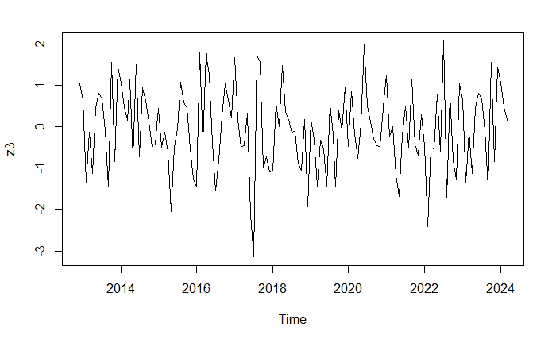

```r
plot(z3)
```

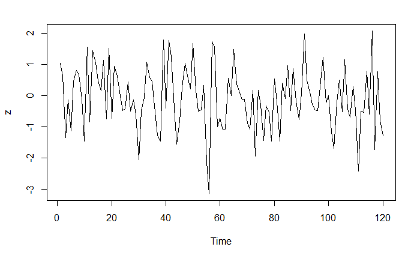

```r
plot(z)
```

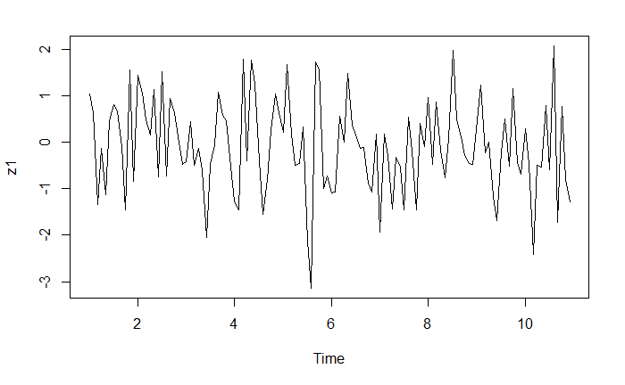

```r
plot(z1)
```

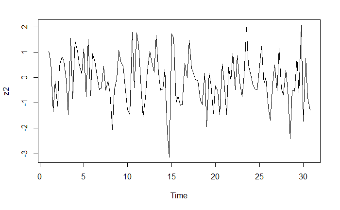

```r
plot(z2)
```

```r
# time step is 1/freq
# it always starts at t = 1
```

Put a starting time

```r
z1 = ts(z, start = 2020, frequency = 4) # starts at quarter 1
z1 = ts(z, start = c(2020,3), frequency = 4) # starts at quarter 3
z1
```

```
             Qtr1         Qtr2         Qtr3         Qtr4
2020                            1.045138691  0.639613109
2021 -1.333304966 -0.137718555 -1.125694758  0.464479048
2022  0.813242804  0.666949629 -0.097294374 -1.453748746
2023  1.556115083 -0.838832885  1.451273075  1.067121442
2024  0.492906947  0.150426059  1.133825363 -0.736954131
2025  1.512795034 -0.727721158  0.938412519  0.635884429
2026  0.114988206 -0.477365615 -0.412861133  0.440068449
2027 -0.499932596 -0.121137644 -0.603516721 -2.053543193
2028 -0.471602429 -0.051773135  1.075377784  0.571770524
2029  0.461505023 -0.540005860 -1.261312291 -1.454065146
2030  1.798456280 -0.390651560  1.767259641  1.249284082
2031 -0.389123506 -1.556030487 -0.794716979  0.253235549
2032  1.049937708  0.640131369  0.212755415  1.680350596
2033  0.169053056 -0.503553986 -0.460338549  0.326555192
```

[output cut: 17 more lines]

```r
#starts at october 2020
z1 = ts(z, start = c(2020,10), frequency = 12)
z1
```

```
              Jan          Feb          Mar          Apr          May          Jun          Jul          Aug
2020
2021 -0.137718555 -1.125694758  0.464479048  0.813242804  0.666949629 -0.097294374 -1.453748746  1.556115083
2022  0.150426059  1.133825363 -0.736954131  1.512795034 -0.727721158  0.938412519  0.635884429  0.114988206
2023 -0.121137644 -0.603516721 -2.053543193 -0.471602429 -0.051773135  1.075377784  0.571770524  0.461505023
2024 -0.390651560  1.767259641  1.249284082 -0.389123506 -1.556030487 -0.794716979  0.253235549  1.049937708
2025 -0.503553986 -0.460338549  0.326555192 -2.129559467 -3.136981417  1.736866842  1.570290977 -0.995349317
2026  0.013826165  1.483950839  0.376222567  0.164410314 -0.133167648 -0.115296347 -0.885533381 -1.070697204
2027 -1.437348728 -0.329369317 -0.537694160 -1.450215831  0.532647538 -0.183555363 -1.450854082  0.406326243
2028 -0.177482606 -0.764057569  0.090215037  1.977551279  0.503192637  0.121787230 -0.277255734 -0.448514419
2029  0.005039095 -1.169927504 -1.683849638 -0.214362873  0.508126230 -0.507106499  1.149517032 -0.441123543
2030 -0.500038374 -0.524246888  0.794189596 -0.590385665  2.082459101 -1.717626421  0.780766803 -0.806785675
              Sep          Oct          Nov          Dec
2020               1.045138691  0.639613109 -1.333304966
2021 -0.838832885  1.451273075  1.067121442  0.492906947
2022 -0.477365615 -0.412861133  0.440068449 -0.499932596
2023 -0.540005860 -1.261312291 -1.454065146  1.798456280
2024  0.640131369  0.212755415  1.680350596  0.169053056
2025 -0.728359991 -1.088841444 -1.078666411  0.558074139
2026  0.177402304 -1.933435660  0.183116938 -0.310997287
2027 -0.097727677  0.959494214 -0.482820295  0.866081518
2028 -0.469236921  0.463612163  1.239579022 -0.221018822
2029 -0.693168954  0.293946825 -0.452338423 -2.412787143
2030 -1.281436448
```

Testing for correlation

```r
Box.test(z, type = "Ljung", lag = 1)
```

```
    Box-Ljung test

data:  z
X-squared = 0.078742, df = 1, p-value = 0.779
```

Since p is greater than alpha, we don’t reject the null hypothesis. H0: p = 0 Since we don’t reject H0, there is no autocorrelation. We don’t proceed with modeling z.

```r
Box.test(ar2.s, type = "Ljung")
```

```
    Box-Ljung test

data:  ar2.s
X-squared = 85.312, df = 1, p-value < 2.2e-16
```

Since p < alpha, we reject H0 and conclude that the data is autocorrelated.

Check for stationarity

```r
adf.test(ma1.1.s)
```

```
    Augmented Dickey-Fuller Test

data:  ma1.1.s
Dickey-Fuller = -8.5157, Lag order = 4, p-value = 0.01
alternative hypothesis: stationary
```

```r
adf.test(ar2.s)
```

```
    Augmented Dickey-Fuller Test

data:  ar2.s
Dickey-Fuller = -5.5523, Lag order = 4, p-value = 0.01
alternative hypothesis: stationary
```

We want to reject H0 for both autocorrelation and stationarity tests.

Since p<alpha for both ar2 and ma1, we reject H0. We conclude that both time series data are stationary.

After we check for autocorrelation and stationarity, we go ahead with modelling.

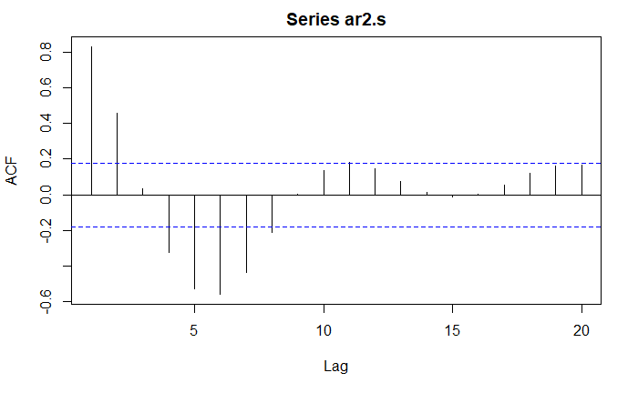

```r
# check where the data cuts off
acf(ar2.s) # cuts off at 8, candidate is ma(8)
```

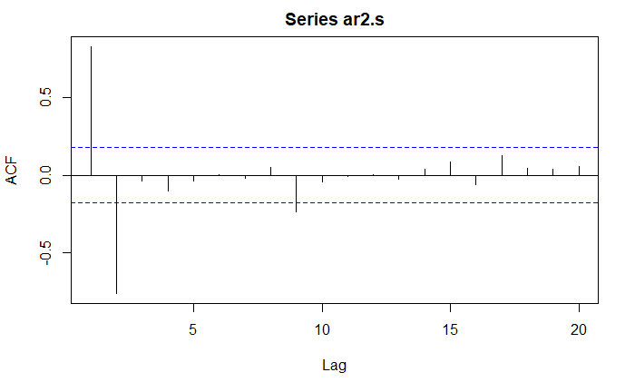

```r
acf(ar2.s, type = "partial") # cuts off at lag 2, we have significant correlation also at lag 9
```

```r
arima(ar2.s, order = c(0,0,8)) # assuming MA(8)
```

```
Call:
arima(x = ar2.s, order = c(0, 0, 8))

Coefficients:
         ma1     ma2     ma3      ma4      ma5      ma6      ma7      ma8  intercept
      1.4706  1.3005  0.7393  -0.0127  -0.5050  -0.5933  -0.5474  -0.2884     0.2186
s.e.  0.0963  0.1637  0.1997   0.2333   0.2439   0.2047   0.1474   0.1080     0.2295

sigma^2 estimated as 0.9236:  log likelihood = -167.11,  aic = 352.23
```

```r
arima(ar2.s, order = c(9,0,0)) # assuming AR(9)
```

```
Call:
arima(x = ar2.s, order = c(9, 0, 0))

Coefficients:
         ar1      ar2     ar3      ar4     ar5      ar6      ar7     ar8      ar9  intercept
      1.4951  -0.8494  0.1319  -0.1304  0.0633  -0.0506  -0.1512  0.3155  -0.2076     0.2276
s.e.  0.0893   0.1620  0.1800   0.1812  0.1839   0.1864   0.1889  0.1705   0.0929     0.2186

sigma^2 estimated as 0.8145:  log likelihood = -159.79,  aic = 339.58
```

```r
arima(ar2.s, order = c(2,0,0)) # assuming AR(2)
```

```
Call:
arima(x = ar2.s, order = c(2, 0, 0))

Coefficients:
         ar1      ar2  intercept
      1.5061  -0.7965     0.2379
s.e.  0.0537   0.0533     0.2927

sigma^2 estimated as 0.862:  log likelihood = -162.98,  aic = 331.95
```

```r
arima(ar2.s, order = c(2,0,8)) #ARMA(2,8)
```

```
Call:
arima(x = ar2.s, order = c(2, 0, 8))

Coefficients:
         ar1      ar2     ma1     ma2     ma3      ma4     ma5      ma6      ma7      ma8  intercept
      1.4204  -0.7537  0.0592  0.0164  0.1135  -0.0093  0.0179  -0.0771  -0.2634  -0.0321     0.2347
s.e.  0.1369   0.1252  0.1656  0.1409  0.1177   0.1287  0.1198   0.1027   0.1071   0.1326     0.2085

sigma^2 estimated as 0.8085:  log likelihood = -159.4,  aic = 340.79
```

```r
arima(ar2.s, order = c(9,0,8)) #ARMA(9,8)
```

```
Call:
arima(x = ar2.s, order = c(9, 0, 8))

Coefficients:
         ar1      ar2      ar3     ar4      ar5     ar6      ar7     ar8     ar9     ma1      ma2      ma3
      1.3789  -0.5849  -0.0764  0.3911  -0.8529  0.7651  -0.0538  -0.202  0.1155  0.1004  -0.0567  -0.0561
s.e.  8.2419  13.6573   8.3121  3.3526   0.6044  4.7125   5.4164   0.565  0.7720  8.2112   1.5681   0.4466
          ma4     ma5      ma6      ma7      ma8  intercept
      -0.4794  0.2673  -0.1435  -0.5055  -0.1265     0.2262
s.e.   2.3177  3.3285   2.6238   0.4535   2.9260     0.0958

sigma^2 estimated as 0.7595:  log likelihood = -158.14,  aic = 352.27
```

```r
# For AR(2),
# X_t = 0.2379 + 1.5061X_t-1 -0.7965 + Z_t
```

We select the best model using log likelihood or AIC. log likelihood - pick the largest AIC - pick the smallest Focus on AIC

The best model for ar2.s is AR(2); it has the smallest AIC. X_t = 0.2379 + 1.5061X_t-1 - 0.7965X_t-2 + Z_t Using S&P 500 data,

```r
data("SP")
SP
```

```
       Qtr1   Qtr2   Qtr3   Qtr4
1936  149.2  148.4  160.1  171.8
1937  179.2  154.0  137.6  105.5
1938   85.0  115.6  122.4  132.1
1939  109.8  108.6  130.2  124.9
1940  122.5   99.8  106.6  105.8
1941   99.6   98.5  102.0   86.9
1942   81.1   83.0   88.5   97.7
1943  115.8  123.5  120.8  116.7
1944  120.2  129.8  127.8  132.8
1945  136.4  149.6  161.6  173.6
1946  180.8  184.3  149.6  153.0
1947  151.7  152.1  151.1  153.0
1948  150.8  167.4  154.9  152.0
1949  150.6  141.6  155.8  167.6
```

[output cut: 28 more lines]

```r
adf.test(SP)
```

```
    Augmented Dickey-Fuller Test

data:  SP
Dickey-Fuller = -3.2617, Lag order = 5, p-value = 0.0799
alternative hypothesis: stationary
```

Since p>alpha, we don’t reject null hypo. Data is not stationary.

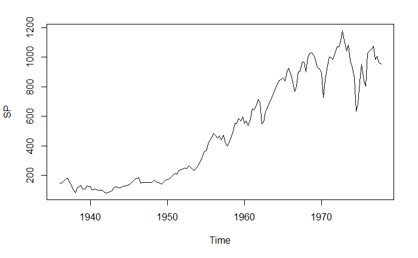

```r
plot(SP)
```

Looking at the graph, the S&P is not stationary it is trending upwards. The means are increasing over time.

We have to do some transformations.

```r
SP.ln = log(SP)
SP.ln
```

```
         Qtr1     Qtr2     Qtr3     Qtr4
1936 5.005288 4.999911 5.075799 5.146331
1937 5.188503 5.036953 4.924351 4.658711
1938 4.442651 4.750136 4.807294 4.883559
1939 4.698661 4.687671 4.869072 4.827513
1940 4.808111 4.603168 4.669084 4.661551
1941 4.601162 4.590057 4.624973 4.464758
1942 4.395683 4.418841 4.483003 4.581902
1943 4.751865 4.816241 4.794136 4.759607
1944 4.789157 4.865995 4.850467 4.888844
1945 4.915592 5.007965 5.085124 5.156754
1946 5.197391 5.216565 5.007965 5.030438
1947 5.021905 5.024538 5.017942 5.030438
1948 5.015954 5.120386 5.042780 5.023881
1949 5.014627 4.953006 5.048573 5.121580
```

[output cut: 28 more lines]

```r
# We take the first difference of the log values
SP.ln.d = diff(SP.ln)
# If its still not stationary, do another diff until stationary
```

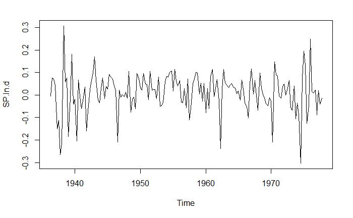

```r
plot(SP.ln.d)
```

```r
adf.test(SP.ln.d)
```

```
    Augmented Dickey-Fuller Test

data:  SP.ln.d
Dickey-Fuller = -5.8697, Lag order = 5, p-value = 0.01
alternative hypothesis: stationary
```

The p value is less than alpha. The differenced data is stationary.

```r
Box.test(SP.ln.d, type = "Ljung")
```

```
    Box-Ljung test

data:  SP.ln.d
X-squared = 2.6772, df = 1, p-value = 0.1018
```

Since p>alpha, we don’t reject null hypothesis. There is no autocorrelation so we don’t continue.

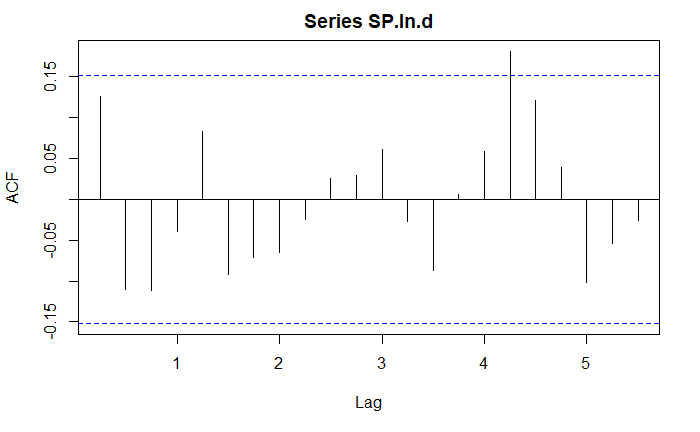

```r
acf(SP.ln.d)
```

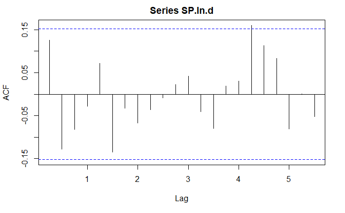

```r
acf(SP.ln.d, type = "partial")
```

```r
# There is only a small overlap at lag 4.
```

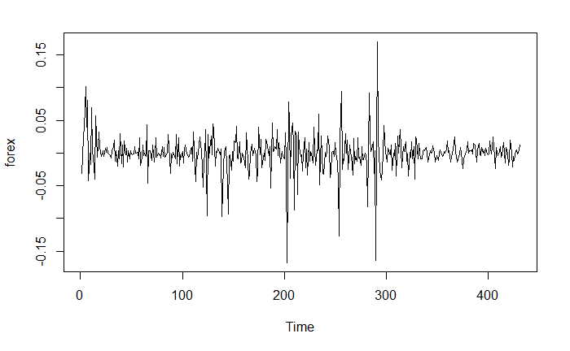

```r
data(usd.hkd)
forex = ts(usd.hkd$hkrate)
plot(forex)
```

Test for stationarity

```r
adf.test(forex)
```

```
    Augmented Dickey-Fuller Test

data:  forex
Dickey-Fuller = -7.7843, Lag order = 7, p-value = 0.01
alternative hypothesis: stationary
```

Since p < alpha, we reject H0. The data is stationary.

```r
Box.test(forex, type = "Ljung")
```

```
    Box-Ljung test

data:  forex
X-squared = 10.491, df = 1, p-value = 0.0012
```

The data is autocorrelated.

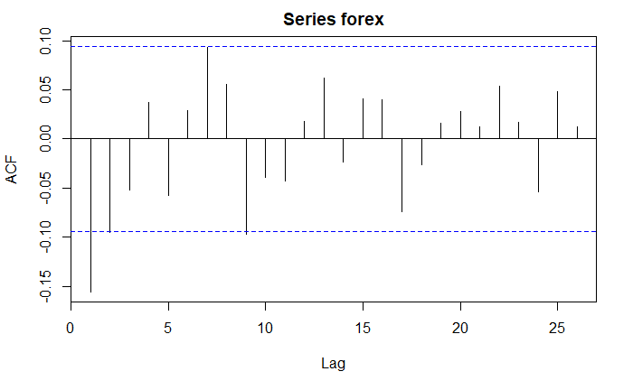

```r
acf(forex) # test MA(1), test MA(2)
```

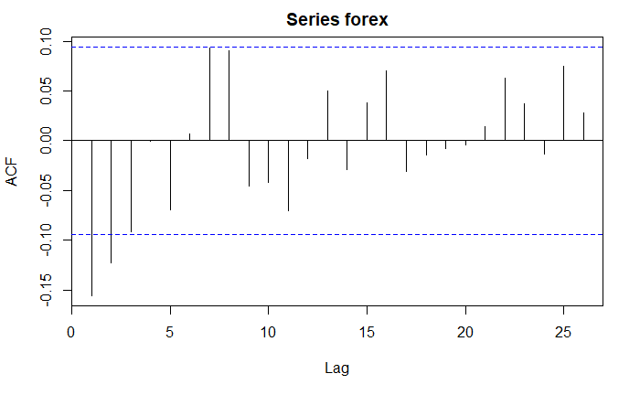

```r
acf(forex, type = "partial") # cuts off at 2, test AR(2)
```

```r
#We check ARMA(2,1) and ARMA(2,2)
arima(forex, order = c(0,0,1)) # MA(1)
```

```
Call:
arima(x = forex, order = c(0, 0, 1))

Coefficients:
          ma1  intercept
      -0.2076     -5e-04
s.e.   0.0544      1e-03

sigma^2 estimated as 0.0007254:  log likelihood = 946.21,  aic = -1888.41
```

```r
arima(forex, order = c(0,0,2)) # MA(2)
```

```
Call:
arima(x = forex, order = c(0, 0, 2))

Coefficients:
          ma1      ma2  intercept
      -0.1932  -0.1094     -5e-04
s.e.   0.0473   0.0454      9e-04

sigma^2 estimated as 0.000716:  log likelihood = 949.01,  aic = -1892.02
```

```r
arima(forex, order = c(2,0,0)) # AR(2)
```

```
Call:
arima(x = forex, order = c(2, 0, 0))

Coefficients:
          ar1      ar2  intercept
      -0.1748  -0.1223     -5e-04
s.e.   0.0479   0.0478      1e-03

sigma^2 estimated as 0.0007203:  log likelihood = 947.75,  aic = -1889.49
```

```r
arima(forex, order = c(2,0,1)) # ARMA(2,1)
```

```
Call:
arima(x = forex, order = c(2, 0, 1))

Coefficients:
         ar1      ar2      ma1  intercept
      0.2899  -0.0588  -0.4763     -5e-04
s.e.  0.1999   0.0657   0.1957      9e-04

sigma^2 estimated as 0.000715:  log likelihood = 949.32,  aic = -1890.64
```

```r
arima(forex, order = c(2,0,2)) # ARMA(2,2)
```

```
Call:
arima(x = forex, order = c(2, 0, 2))

Coefficients:
         ar1      ar2      ma1     ma2  intercept
      1.3367  -0.7984  -1.4935  0.8923    -0.0004
s.e.  0.0965   0.0721   0.0818  0.0758     0.0011

sigma^2 estimated as 0.0007033:  log likelihood = 952.65,  aic = -1895.3
```

ARMA(2,2) has the lowest AIC so its the best model. X_t = -0.0004 + 1.3367X_t-1 - 0.7984X_t-2 + Z_t - 1.4935Z_t-1 + 0.8923Z_t-2

Test significance of variables

```r
coeftest(arima(forex, order = c(2,0,2)))
```

```
z test of coefficients:

            Estimate Std. Error  z value Pr(>|z|)
ar1        1.3366626  0.0965139  13.8494   <2e-16 ***
ar2       -0.7983596  0.0720686 -11.0778   <2e-16 ***
ma1       -1.4934556  0.0817889 -18.2599   <2e-16 ***
ma2        0.8922821  0.0758252  11.7676   <2e-16 ***
intercept -0.0004219  0.0011042  -0.3821   0.7024
---
Signif. codes:  0 ‘***’ 0.001 ‘**’ 0.01 ‘*’ 0.05 ‘.’ 0.1 ‘ ’ 1
```

All of our coefficients except for the intercept are significant since their p values are less than 0.05.

```r
forex
```

```
Time Series:
Start = 1
End = 431
Frequency = 1
  [1] -0.030868960 -0.006432233  0.025726450  0.038577270  0.101515700  0.039807130  0.080849570 -0.042341620
  [9]  0.000000000 -0.017968530  0.069289400  0.005130639 -0.020524140 -0.039777500  0.056453680 -0.006413587
 [17]  0.011544160  0.032060120  0.008974992 -0.005128468 -0.002564333  0.003846474 -0.005128665  0.007692900
 [25]  0.001282092  0.008974186  0.000000000 -0.002563971 -0.003846080 -0.007692604  0.003846376  0.010256280
 [33]  0.019227690 -0.012818050  0.003845587 -0.020511510  0.003846228 -0.008974762  0.029485480 -0.016664640
 [41]  0.012819200 -0.021793610  0.017948030 -0.002563807  0.007691223 -0.014101030  0.003845932 -0.008974071
 [49]  0.003846129 -0.001282027 -0.002564103 -0.001282076  0.010256150  0.000000000  0.000000000  0.001281944
 [57] -0.008973956  0.023074260 -0.019228180 -0.006410215  0.012820020 -0.003845833  0.000000000 -0.005128008
 [65]  0.043579690 -0.046143790  0.003846129  0.003845981 -0.005128008 -0.011538980  0.012821010 -0.014103200
 [73] -0.001282207  0.023077220 -0.006409804  0.000000000 -0.002564037 -0.001282043 -0.007692604  0.010256670
 [81] -0.005128205  0.008974186 -0.006410051 -0.002564135  0.000000000  0.028201870  0.011534840 -0.030762530
```

[output cut: 43 more lines]